# Predicting Lending Club database

In this project, working with the Lending Club loan data, we hope to correctly predict whether or not on loan will be default using the history data.

# Contents

1. Problem Statement

   0.1 About the dataset

   0.2 Goal and questions

   0.3 Results
1. Exploring data
1. Feature Selection

   2.1 Financial knowledge

   2.2 NAs values

   2.3 Correlation analysis
1. Data cleaning

   3.1 Financial knowledge

   3.2 NAs values

   3.3 Correlation analysis
1. Feature Engineering

   4.1 Feature Parsing

   4.2 Mean encoding

   4.3 Generation of dummies

   4.4 Feature Scaling

   4.5 Relevant Features

   4.6 Split in train and test
1. Data Visualization
1. Prediction Models

   6.1 Logistic Regression

   6.2 Support Vector Machine

   ```
    Random search SVC
   ```

   6.3 Random Forest

   ```
    Random forest with random search
   ```

   6.4 XGBoost

   ```
    XGBoost with random search
   ```

   6.5 Gradient Boosting

# 0. Problem statment

## 0.1 About the Dataset

These files contain loan data in the 2007-2019 period, including the current loan status and the latest payment information.

Features include number of financial inquiries, zip code addresses and status. The file is a matrix of 2.260.668 observations and 145 features. A data dictionary is provided in a separate file.

## 0.2. Goal and Questions

Our goal is to build a machine learning algorithm for the prediction of loan granting in the current features in the database. To achieve this, we will perform an analysis of the database trying to answer the following questions:

1) What type of features do we have in the dataset?

2) Are there any features that filter information or aren't relevant?

3) What degree of relationship do the variables have? Are there missing values? How do we impute them?

4) What variables are more important in prediction models?

5) What prediction model shows better results?

## 0.3. Results and Conclusions

Answering the previous questions we have detected that there are three kinds of data in the dataset, strings, booleans and numerics. All of all features included in the dataset (145) we have keeped only a few of them which we consider they have the most relevant information for for the goal we have set.

Many features included in the dataset filtered information about our objective to predict because they were collected at a time after the credit has been granted.

Also a large number of features were incomplete, having missing vaules for more than 60% of the records.

After performing multiple machine learning models, we represent the combination of ROC curves obtained by the models through a plot.

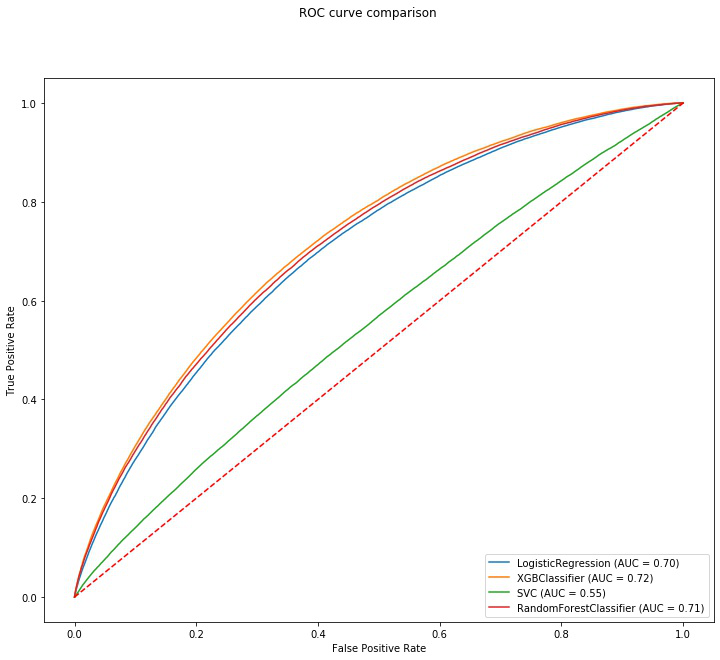

```python
from PIL import Image
img  = Image.open("../images/ROCs.jpg")
img
```

In the plot we can see how the Logistic Regression, XGBoost and Random Forest obtain similar results. Although, XGBoost is the model which obtains the best results.

In fact, one of the biggest problems we have experienced has been achieving good results in the Support Vectore Machine model, that's why it appears on the graph so far from the rest of the models.

These model have been selected after performing an hyperparameter tuning for obtaining the best results out of each model.

After analyzing the importance of the variables within each model we have perceived that the variables "sub_grade", "int_rate" and "dti" are the ones that appear with the greatest relevance in most models.

For the best model (XGBoost) the most relevant features are the following:

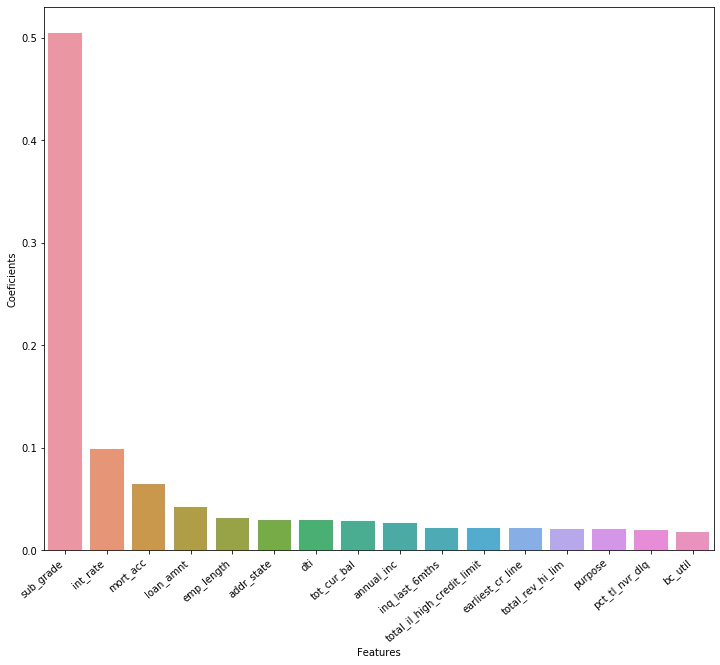

```python
img2  = Image.open("../images/XGBoost_feature_importance.jpg")
img2
```

Finally we made an ensemble of two models to improve our recall of the minority class. In this ensemble we lost 4% accuracy in comparation with our best model, but we think that the improvement in the recall of the minority class is worth.